# Bayesian partial pooling for estimation of sector betas

Bayesian hierarchical models, or partial pooling, have been gaining more relevance throughout the years. Ever since the benchmark "eight schools" study of Rubin (1981), hierarchical models have made their way into the Bayesian toolbox.

Partial pooling is particularly useful when our data comes into "clusters", and the assumption that the parameter for one cluster may contain useful information regarding others seems reasonable.

The usual approaches either assume the data in different clusters comes from the same distribution (full pooling), or that the clusters are completely separate and do not contain information about each other (unpooled).

In the case of partial pooling, we assume the data from each cluster is drawn from different parameters, but these parameters are drawn from the same distribution, thereby being called hierarchical.

In Rubin's eight schools example, Rubin sought to measure the effects of SAT-specific courses on students' outcomes when taking the SAT. The clusters were each of the schools where the courses were taught. Both the assumptions that the schools did not contain any information about each other, or that the students' outcomes in different schools were drawn from the exact same distribution seemed unreasonable.

We can try and apply partial pooling in the context of the cross section of returns

Remember the CAPM model: we describe the returns of each stock as a function of the market return. It turns out companies listed in the S&P 500 can be grouped into sectors. These could work as our clusters.

First we start off by scraping the return data from Yahoo Finance

```python
import numpy as np
import pandas as pd
import matplotlib.pyplot as plt
import yfinance as yf
import pymc as pm
import arviz as az
%matplotlib inline
```

```
WARNING (aesara.tensor.blas): Using NumPy C-API based implementation for BLAS functions.
```

```python
companies = pd.read_csv("https://datahub.io/core/s-and-p-500-companies/r/constituents.csv")

tickers = companies["Symbol"]
tickers_list = tickers.tolist()
tickers_list = list(map(lambda x: str.replace(x, ".", "-"), tickers_list))

start_date = "2016-01-01"
end_date = "2020-01-01"

spy = yf.Ticker("SPY").history(start = start_date, end = end_date)
spy_ret = spy['Close'].pct_change().dropna()

returns_df = pd.DataFrame()
for i in tickers_list:
    price = yf.Ticker(i).history(start = start_date, end = end_date)
    ret = price['Close'].pct_change().dropna()
    # returns_df[i] = ret
    returns_df = pd.concat((returns_df, ret.rename(i)), axis=1)
returns_df.columns = tickers_list
returns_df.dropna(axis=1, inplace=True)
returns_df
```

[output not shown]

|  | MMM | AOS | ABT | ABBV | ABMD | ACN | ATVI | ADM | ADBE | AAP | ... | WHR | WMB | WYNN | XEL | XYL | YUM | ZBRA | ZBH | ZION | ZTS |
| --- | --- | --- | --- | --- | --- | --- | --- | --- | --- | --- | --- | --- | --- | --- | --- | --- | --- | --- | --- | --- | --- |
| 2016-01-05 | 0.004359 | -0.005587 | -0.000233 | -0.004166 | -0.002816 | 0.005205 | -0.012759 | 0.011161 | 0.004023 | -0.006832 | ... | -0.021541 | 0.003430 | 0.018904 | 0.010084 | -0.000277 | -0.002493 | -0.025117 | 0.020823 | -0.010857 | 0.015655 |
| 2016-01-06 | -0.020141 | -0.019797 | -0.008387 | 0.000174 | 0.003529 | -0.001954 | -0.009424 | -0.024283 | -0.014295 | -0.026455 | ... | -0.025535 | -0.130270 | -0.051805 | 0.010538 | -0.012476 | -0.007080 | -0.039957 | 0.004330 | -0.029144 | 0.000208 |
| 2016-01-07 | -0.024362 | -0.048854 | -0.023966 | -0.002963 | -0.039625 | -0.029365 | -0.014134 | -0.023756 | -0.020984 | 0.011074 | ... | -0.025142 | -0.100000 | -0.094070 | 0.003842 | -0.025829 | -0.034116 | -0.045316 | -0.022993 | -0.030020 | -0.030404 |
| 2016-01-08 | -0.003405 | -0.035581 | -0.020944 | -0.027268 | 0.032471 | -0.009682 | -0.015440 | -0.003766 | -0.014140 | -0.021972 | ... | -0.015183 | -0.014556 | -0.040704 | -0.010935 | -0.009510 | -0.013607 | -0.002693 | -0.004217 | -0.011254 | -0.014605 |
| 2016-01-11 | -0.000214 | -0.025885 | 0.001475 | -0.031806 | 0.004966 | 0.010489 | 0.014002 | -0.006688 | 0.017416 | 0.010237 | ... | -0.008483 | -0.079764 | -0.016453 | 0.008015 | -0.008438 | -0.001761 | -0.006582 | -0.017233 | -0.019919 | -0.028335 |
| ... | ... | ... | ... | ... | ... | ... | ... | ... | ... | ... | ... | ... | ... | ... | ... | ... | ... | ... | ... | ... | ... |
| 2019-12-24 | -0.010030 | 0.007637 | -0.000801 | -0.004432 | 0.010913 | 0.003700 | -0.001358 | 0.001304 | 0.002098 | 0.003751 | ... | -0.002062 | -0.004177 | -0.005634 | 0.003913 | -0.003926 | 0.005210 | -0.009348 | -0.002447 | 0.003701 | 0.004155 |
| 2019-12-26 | -0.000509 | 0.005053 | 0.000000 | -0.000223 | -0.007487 | 0.002079 | 0.001360 | 0.002604 | 0.004732 | -0.008096 | ... | 0.000069 | -0.001258 | 0.010757 | -0.001114 | -0.000509 | 0.014552 | 0.000354 | -0.002191 | 0.002523 | 0.000827 |
| 2019-12-27 | 0.003794 | 0.001466 | 0.001375 | -0.007013 | -0.010175 | 0.000802 | 0.005094 | 0.002164 | -0.001238 | -0.005777 | ... | 0.005028 | -0.009240 | -0.008018 | 0.005256 | 0.003053 | 0.001081 | 0.006210 | -0.001929 | -0.003097 | 0.001654 |
| 2019-12-30 | -0.008067 | -0.005020 | -0.006865 | -0.007623 | -0.011697 | -0.007445 | -0.005237 | -0.003888 | -0.007407 | 0.004863 | ... | 0.002056 | -0.016532 | -0.003075 | 0.002693 | -0.001268 | -0.012365 | -0.007383 | -0.008400 | 0.005243 | -0.007805 |
| 2019-12-31 | 0.003355 | 0.001472 | 0.000691 | 0.000226 | 0.019726 | -0.000332 | 0.009171 | 0.004987 | 0.004477 | 0.006536 | ... | 0.008959 | 0.022414 | -0.003659 | 0.003160 | 0.000635 | 0.000894 | 0.005234 | 0.006252 | 0.002897 | 0.001059 |

1005 rows × 482 columns

Now we shall set up a multilevel dataframe, with companies and sectors as levels

```python
drop_cols = []
for i in tickers_list:
    if i not in returns_df.columns:
        drop_cols.append(i)
drop_cols

companies_new = companies.drop(companies[companies["Symbol"].isin(drop_cols)].index).sort_values(by="Sector")

tuples = list(zip(companies_new['Sector'],companies_new['Symbol']))
columns = pd.MultiIndex.from_tuples(tuples, names=["Sector", "Symbol"])

returns_df.columns = columns
returns_df
```

| Sector Symbol | Communication Services T | Communication Services CMCSA | Communication Services GOOGL | Communication Services IPG | Communication Services NWS | Communication Services NWSA | Communication Services DISH | Communication Services NFLX | Communication Services CHTR | Communication Services DIS | ... | Utilities EIX | Utilities NRG | Utilities ATO | Utilities ETR | Utilities NEE | Utilities PEG | Utilities AWK | Utilities AEP | Utilities CNP | Utilities NI |
| --- | --- | --- | --- | --- | --- | --- | --- | --- | --- | --- | --- | --- | --- | --- | --- | --- | --- | --- | --- | --- | --- |
| 2016-01-05 | 0.004359 | -0.005587 | -0.000233 | -0.004166 | -0.002816 | 0.005205 | -0.012759 | 0.011161 | 0.004023 | -0.006832 | ... | -0.021541 | 0.003430 | 0.018904 | 0.010084 | -0.000277 | -0.002493 | -0.025117 | 0.020823 | -0.010857 | 0.015655 |
| 2016-01-06 | -0.020141 | -0.019797 | -0.008387 | 0.000174 | 0.003529 | -0.001954 | -0.009424 | -0.024283 | -0.014295 | -0.026455 | ... | -0.025535 | -0.130270 | -0.051805 | 0.010538 | -0.012476 | -0.007080 | -0.039957 | 0.004330 | -0.029144 | 0.000208 |
| 2016-01-07 | -0.024362 | -0.048854 | -0.023966 | -0.002963 | -0.039625 | -0.029365 | -0.014134 | -0.023756 | -0.020984 | 0.011074 | ... | -0.025142 | -0.100000 | -0.094070 | 0.003842 | -0.025829 | -0.034116 | -0.045316 | -0.022993 | -0.030020 | -0.030404 |
| 2016-01-08 | -0.003405 | -0.035581 | -0.020944 | -0.027268 | 0.032471 | -0.009682 | -0.015440 | -0.003766 | -0.014140 | -0.021972 | ... | -0.015183 | -0.014556 | -0.040704 | -0.010935 | -0.009510 | -0.013607 | -0.002693 | -0.004217 | -0.011254 | -0.014605 |
| 2016-01-11 | -0.000214 | -0.025885 | 0.001475 | -0.031806 | 0.004966 | 0.010489 | 0.014002 | -0.006688 | 0.017416 | 0.010237 | ... | -0.008483 | -0.079764 | -0.016453 | 0.008015 | -0.008438 | -0.001761 | -0.006582 | -0.017233 | -0.019919 | -0.028335 |
| ... | ... | ... | ... | ... | ... | ... | ... | ... | ... | ... | ... | ... | ... | ... | ... | ... | ... | ... | ... | ... | ... |
| 2019-12-24 | -0.010030 | 0.007637 | -0.000801 | -0.004432 | 0.010913 | 0.003700 | -0.001358 | 0.001304 | 0.002098 | 0.003751 | ... | -0.002062 | -0.004177 | -0.005634 | 0.003913 | -0.003926 | 0.005210 | -0.009348 | -0.002447 | 0.003701 | 0.004155 |
| 2019-12-26 | -0.000509 | 0.005053 | 0.000000 | -0.000223 | -0.007487 | 0.002079 | 0.001360 | 0.002604 | 0.004732 | -0.008096 | ... | 0.000069 | -0.001258 | 0.010757 | -0.001114 | -0.000509 | 0.014552 | 0.000354 | -0.002191 | 0.002523 | 0.000827 |
| 2019-12-27 | 0.003794 | 0.001466 | 0.001375 | -0.007013 | -0.010175 | 0.000802 | 0.005094 | 0.002164 | -0.001238 | -0.005777 | ... | 0.005028 | -0.009240 | -0.008018 | 0.005256 | 0.003053 | 0.001081 | 0.006210 | -0.001929 | -0.003097 | 0.001654 |
| 2019-12-30 | -0.008067 | -0.005020 | -0.006865 | -0.007623 | -0.011697 | -0.007445 | -0.005237 | -0.003888 | -0.007407 | 0.004863 | ... | 0.002056 | -0.016532 | -0.003075 | 0.002693 | -0.001268 | -0.012365 | -0.007383 | -0.008400 | 0.005243 | -0.007805 |
| 2019-12-31 | 0.003355 | 0.001472 | 0.000691 | 0.000226 | 0.019726 | -0.000332 | 0.009171 | 0.004987 | 0.004477 | 0.006536 | ... | 0.008959 | 0.022414 | -0.003659 | 0.003160 | 0.000635 | 0.000894 | 0.005234 | 0.006252 | 0.002897 | 0.001059 |

1005 rows × 482 columns

Recall the CAPM model for how companies' returns can be predicted by the market factor. We can estimate a CAPM model for each of the companies, therefore obtaining a market beta for every single company, or we could group them all together, obtaining a single beta for the whole S&P500.

This last approach would be redundant, as our predictor variable (SPY) is already the returns for the S&P 500. In this case we would obtain an alpha very close to zero and a beta very close to 1. This approach, however, could be valid for a subset of the S&P 500 stocks.

Or we could use the information that stocks are grouped into sectors and try to use the CAPM to estimate sector betas. We have already introduced Bayesian multilevel modelling in a previous post, an approach that could be useful for this.

### Noncentered parametrization for multilevel models

Before jumping into our model, we also need to introduce one more aspect of Bayesian multilevel models: centered and noncentered parametrizations. A centered parametrization would be the intuitive way to specify a multilevel model. A simple centered multilevel model could look like

$\mu \sim N(0,1)$,

$\sigma \sim HalfCauchy(1)$,

$\beta_j \sim N(\mu,\sigma^2)$,

$y_{i,j} \sim N(\beta_j x_{i,j}, 1)$.

An MCMC sample might have trouble here because $\mu$ and $\beta_j$ can be correlated, so the sampler has issues exploring the parameter space. Ben Lambert gives a good overview of the problem here: https://www.youtube.com/watch?v=gSd1msFFZTw

We can improve things by using a noncentered parametrization, which would look like

$\mu \sim N(0,1)$,

$\sigma \sim HalfCauchy(1)$,

$Z_j \sim N(0,1)$,

$\beta_j = \mu + \sigma Z_j$,

$y_{i,j} \sim N(\beta_j x_{i,j}, 1)$.

The difference is mathematically subtle, but can have a lot of difference computationally. From probability theory we know how to standardize a normal distribution, and what we do here can be viewed as the reverse: instead of subtracting the mean and dividing by the standard deviation in order to obtain the standard normal, we start from the standard normal, multiply by the SD and add the mean to obtain our normally distributed variable. It turns out that, for the fact that $\mu$ and $Z_j$ are uncorrelated, the sampler has a much easier time exploring the parameter space. For a more thorough explanation see: https://twiecki.io/blog/2014/03/17/bayesian-glms-3/

Now let's specify our multilevel CAPM with sectors as clusters

```python
sector_list = companies_new["Sector"].unique()
n_sectors = companies_new["Sector"].nunique()
T = len(spy_ret)

sector_idxs, sectors = pd.factorize(companies_new.Sector.reset_index(drop=1))
coords = {
    "sector": sectors,
    "obs_id": np.arange(len(sector_idxs))
}

with pm.Model(coords=coords) as hierarchical_capm:

    sector_idx = pm.Data("sector_idx", sector_idxs, dims="obs_id", mutable=False)

    mu_alpha = pm.Normal("mu_alpha", 0, 1)
    sigma_alpha = pm.HalfCauchy("sigma_alpha", 1)
    mu_beta = pm.Normal("mu_beta", 0, 1)
    sigma_beta = pm.HalfCauchy("sigma_beta", 1)

    # centered:
    # alpha = pm.Normal("alpha", mu_alpha, sigma_alpha, dims="sector")
    # noncentered:
    alpha = pm.Deterministic('alpha', mu_alpha + sigma_alpha * pm.Normal("z_alpha", 0, 1, shape=n_sectors), dims="sector")

    # centered:
    # beta = pm.Normal("beta", mu_beta, sigma_beta, dims="sector")
    # noncentered:
    beta = pm.Deterministic("beta", mu_beta + sigma_beta * pm.Normal("z_beta", 0, 1, shape=n_sectors), dims="sector")

    error = pm.HalfCauchy("error", 1)
    stock_return = alpha[sector_idx] + beta[sector_idx] * spy_ret.values.reshape((-1,1))

    y = pm.Normal('likelihood', mu = stock_return, sigma = error, observed = returns_df.values)
pm.model_to_graphviz(hierarchical_capm)
```

[figure not shown]

```python
with hierarchical_capm:
    trace_hcapm = pm.sample(2000, tune=1000, target_accept=0.8, return_inferencedata=True, chains=2)
```

```
Auto-assigning NUTS sampler...
Initializing NUTS using jitter+adapt_diag...
Multiprocess sampling (2 chains in 4 jobs)
NUTS: [mu_alpha, sigma_alpha, mu_beta, sigma_beta, z_alpha, z_beta, error]
```

100.00% [6000/6000 4:31:56<00:00 Sampling 2 chains, 8 divergences]

```
Sampling 2 chains for 1_000 tune and 2_000 draw iterations (2_000 + 4_000 draws total) took 16330 seconds.
There were 5 divergences after tuning. Increase `target_accept` or reparameterize.
There were 3 divergences after tuning. Increase `target_accept` or reparameterize.
```

```
array([[<AxesSubplot:title={'center':'mu_alpha'}>,
        <AxesSubplot:title={'center':'mu_alpha'}>],
       [<AxesSubplot:title={'center':'mu_beta'}>,
        <AxesSubplot:title={'center':'mu_beta'}>],
       [<AxesSubplot:title={'center':'sigma_alpha'}>,
        <AxesSubplot:title={'center':'sigma_alpha'}>],
       [<AxesSubplot:title={'center':'sigma_beta'}>,
        <AxesSubplot:title={'center':'sigma_beta'}>],
       [<AxesSubplot:title={'center':'error'}>,
        <AxesSubplot:title={'center':'error'}>],
       [<AxesSubplot:title={'center':'alpha'}>,
        <AxesSubplot:title={'center':'alpha'}>],
       [<AxesSubplot:title={'center':'beta'}>,
        <AxesSubplot:title={'center':'beta'}>]], dtype=object)
```

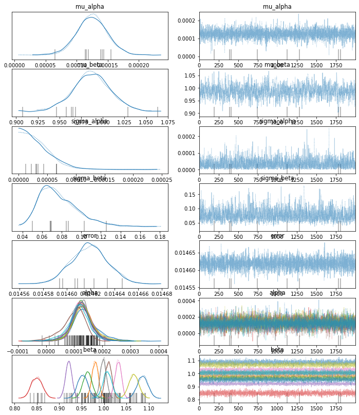

```python
az.plot_trace(trace_hcapm, var_names=["~z_alpha", "~z_beta"])
```

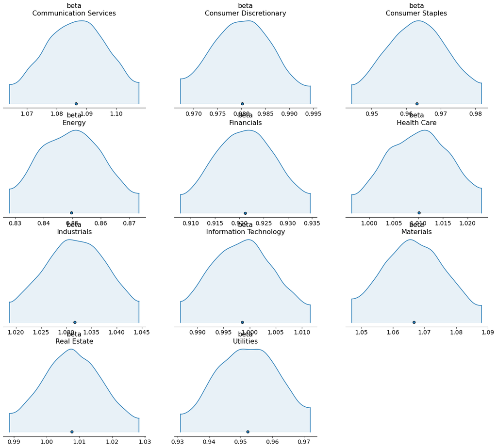

```python
az.plot_density(trace_hcapm,var_names=["beta"],shade=0.1)
plt.show()
```

These posteriors for the market betas can give us an idea of which sectors are more or less sensitive to the market.